# Regression

Joseph Rickert

March 22, 2016

## Regression Analysis

This module takes you the process of fitting a multiple regression model. The data come from the UCI machine Learning Repository. The data is described here: https://archive.ics.uci.edu/ml/machine-learning-databases/auto-mpg/auto-mpg.names, and here: http://cs.nyu.edu/courses/fall00/G22.3033-001/weka/weka-3-0-2/data/auto-mpg.arff

### Setup

Here we load the required libraries and a user defined function

```r
library(ggplot2)
library(dplyr)
library(corrplot)

# Function to divide data into training, and test sets
index <- function(data=data,pctTrain=0.7)
{
  # fcn to create indices to divide data into random
  # training, validation and testing data sets
  N <- nrow(data)
  train <- sample(N, pctTrain*N)
  test <- setdiff(seq_len(N),train)
  Ind <- list(train=train,test=test)
  return(Ind)
}
```

### DATA

We fetch data from the UCI MAchine Learning Repository

```r
url <-"https://archive.ics.uci.edu/ml/machine-learning-databases/auto-mpg/auto-mpg.data"
mpg <- read.table(url,stringsAsFactors = FALSE,na.strings="?")

# For later use: write to disk and read in again
write.csv(mpg,"mpg_orig.csv",row.names=FALSE)
mpg <- read.csv("mpg_orig.csv")
```

### Data Preparation

```r
#Look at the data and reset some of the data types
names(mpg) <- c("mpg","cyl","disp","hp","weight","accel","year","origin","name")
head(mpg)
```

```
##   mpg cyl disp  hp weight accel year origin                      name
## 1  18   8  307 130   3504  12.0   70      1 chevrolet chevelle malibu
## 2  15   8  350 165   3693  11.5   70      1         buick skylark 320
## 3  18   8  318 150   3436  11.0   70      1        plymouth satellite
## 4  16   8  304 150   3433  12.0   70      1             amc rebel sst
## 5  17   8  302 140   3449  10.5   70      1               ford torino
## 6  15   8  429 198   4341  10.0   70      1          ford galaxie 500
```

```r
dim(mpg)
```

```
## [1] 398   9
```

```r
# Count the numberof missing values in the data
length(which(is.na(mpg))==TRUE)
```

```
## [1] 6
```

```r
# Remove the missing values since there are only six of them
# In a serious work you might want to think about imputing
# or setimating the missing values
mpg <- na.omit(mpg)

sapply(mpg,class)
```

```
##       mpg       cyl      disp        hp    weight     accel      year
## "numeric" "integer" "numeric" "integer" "integer" "numeric" "integer"
##    origin      name
## "integer"  "factor"
```

```r
summary(mpg)
```

```
##       mpg             cyl             disp             hp
##  Min.   : 9.00   Min.   :3.000   Min.   : 68.0   Min.   : 46.0
##  1st Qu.:17.00   1st Qu.:4.000   1st Qu.:105.0   1st Qu.: 75.0
##  Median :22.75   Median :4.000   Median :151.0   Median : 93.5
##  Mean   :23.45   Mean   :5.472   Mean   :194.4   Mean   :104.5
##  3rd Qu.:29.00   3rd Qu.:8.000   3rd Qu.:275.8   3rd Qu.:126.0
##  Max.   :46.60   Max.   :8.000   Max.   :455.0   Max.   :230.0
##
##      weight         accel            year           origin
##  Min.   :1613   Min.   : 8.00   Min.   :70.00   Min.   :1.000
##  1st Qu.:2225   1st Qu.:13.78   1st Qu.:73.00   1st Qu.:1.000
##  Median :2804   Median :15.50   Median :76.00   Median :1.000
##  Mean   :2978   Mean   :15.54   Mean   :75.98   Mean   :1.577
##  3rd Qu.:3615   3rd Qu.:17.02   3rd Qu.:79.00   3rd Qu.:2.000
##  Max.   :5140   Max.   :24.80   Max.   :82.00   Max.   :3.000
##
##                  name
##  amc matador       :  5
##  ford pinto        :  5
##  toyota corolla    :  5
##  amc gremlin       :  4
##  amc hornet        :  4
##  chevrolet chevette:  4
##  (Other)           :365
```

```r
mpg <- mutate(mpg, hp = as.numeric(hp),
              year = as.factor(year),
              origin = as.factor(origin))
sapply(mpg,class)
```

```
##       mpg       cyl      disp        hp    weight     accel      year
## "numeric" "integer" "numeric" "numeric" "integer" "numeric"  "factor"
##    origin      name
##  "factor"  "factor"
```

### Exploratory Data Analysis

In this section we look at numerical summaries of the data as well as various plots to visualize relationships among the variables

```r
summary(mpg)
```

```
##       mpg             cyl             disp             hp
##  Min.   : 9.00   Min.   :3.000   Min.   : 68.0   Min.   : 46.0
##  1st Qu.:17.00   1st Qu.:4.000   1st Qu.:105.0   1st Qu.: 75.0
##  Median :22.75   Median :4.000   Median :151.0   Median : 93.5
##  Mean   :23.45   Mean   :5.472   Mean   :194.4   Mean   :104.5
##  3rd Qu.:29.00   3rd Qu.:8.000   3rd Qu.:275.8   3rd Qu.:126.0
##  Max.   :46.60   Max.   :8.000   Max.   :455.0   Max.   :230.0
##
##      weight         accel            year     origin
##  Min.   :1613   Min.   : 8.00   73     : 40   1:245
##  1st Qu.:2225   1st Qu.:13.78   78     : 36   2: 68
##  Median :2804   Median :15.50   76     : 34   3: 79
##  Mean   :2978   Mean   :15.54   75     : 30
##  3rd Qu.:3615   3rd Qu.:17.02   82     : 30
##  Max.   :5140   Max.   :24.80   70     : 29
##                                 (Other):193
##                  name
##  amc matador       :  5
##  ford pinto        :  5
##  toyota corolla    :  5
##  amc gremlin       :  4
##  amc hornet        :  4
##  chevrolet chevette:  4
##  (Other)           :365
```

```r
# Look at correlations among the numeric variables
mpg.num <- select(mpg,mpg,cyl,disp,hp,weight,accel)
cor(mpg.num)
```

```
##               mpg        cyl       disp         hp     weight      accel
## mpg     1.0000000 -0.7776175 -0.8051269 -0.7784268 -0.8322442  0.4233285
## cyl    -0.7776175  1.0000000  0.9508233  0.8429834  0.8975273 -0.5046834
## disp   -0.8051269  0.9508233  1.0000000  0.8972570  0.9329944 -0.5438005
## hp     -0.7784268  0.8429834  0.8972570  1.0000000  0.8645377 -0.6891955
## weight -0.8322442  0.8975273  0.9329944  0.8645377  1.0000000 -0.4168392
## accel   0.4233285 -0.5046834 -0.5438005 -0.6891955 -0.4168392  1.0000000
```

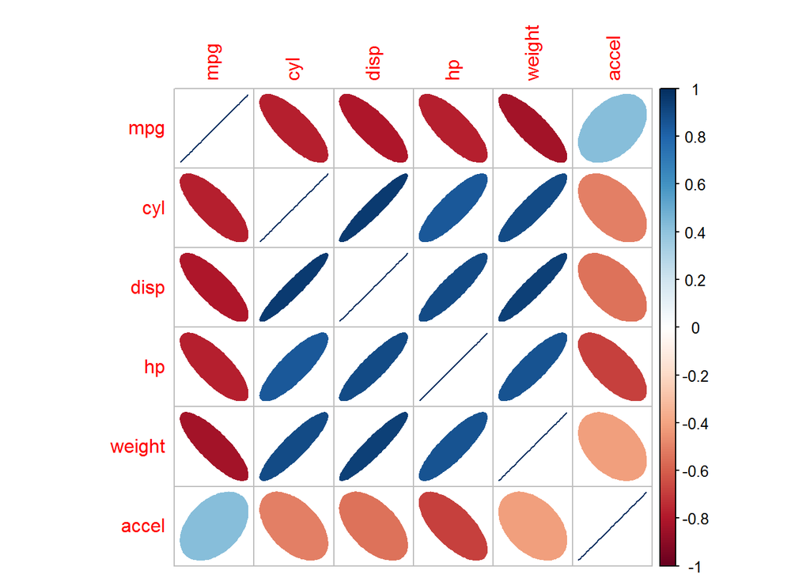

```r
corrplot(cor(mpg.num), method="ellipse")
```

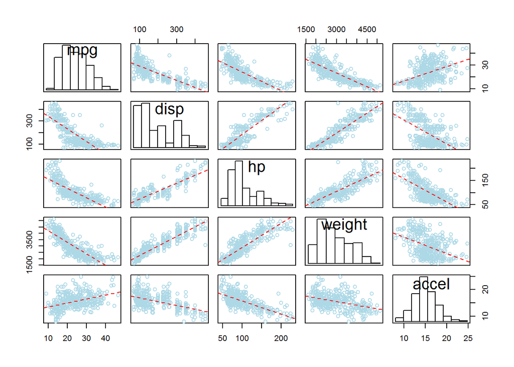

```r
# Look at the at pairwise relationships for continuous variables
pairs(mpg[,c(1,3:6)],                    # pairs is function that produces a maatrix of scatter plots
      panel=function(x,y){               # define a function panel for the content of the matrix
        points(x,y, col="light blue")                       # plot the points
        abline(lm(y~x), lty=2,col="red") # add a linear regression
      },
      diag.panel=function(x){            # define a new panel for the diagonals
        par(new=T)
        hist(x,main="",axes=F,nclass=12) # put a histogram on each diagonal
      }
)
```

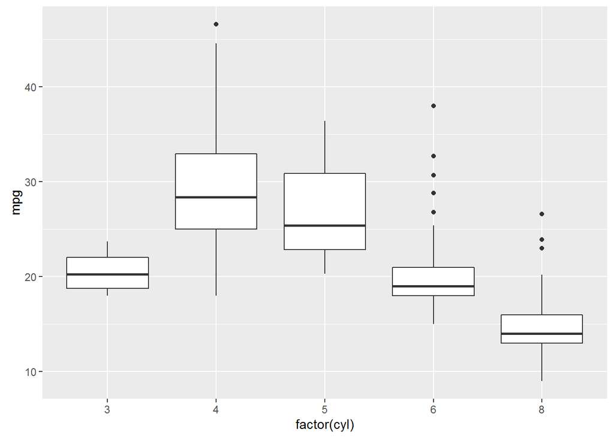

```r
# Look at distribution of mpg for discrete variables
# mpg by cyl
p1 <- ggplot(mpg, aes(factor(cyl),mpg))
p1 + geom_boxplot()
```

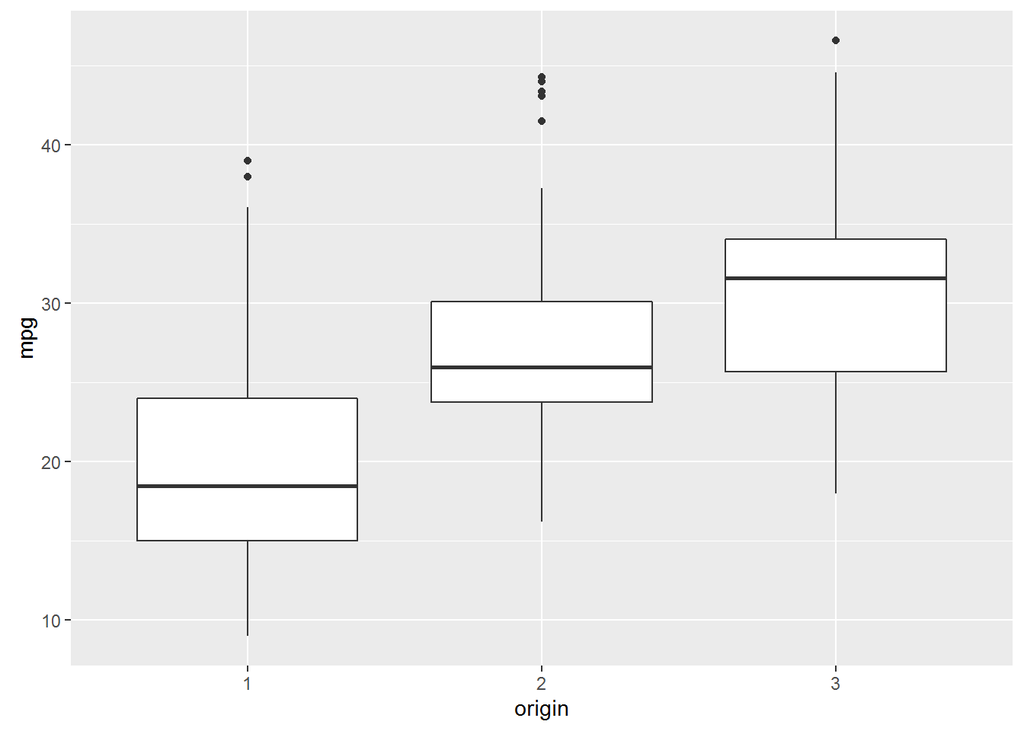

```r
# Plot mpg as a function of origin
# origin: 1 = USA, 2 = Europe, 3 = Japan
p2 <- ggplot(mpg, aes(origin,mpg))
p2 + geom_boxplot()
```

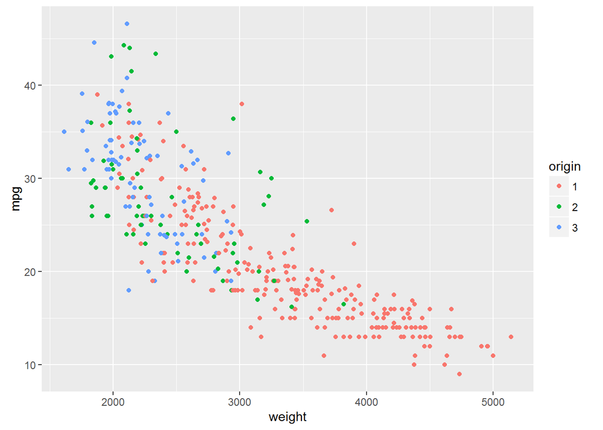

```r
# Plot mpg by weight and origin
p3 <- ggplot(mpg, aes(weight,mpg,col=origin))
p3 + geom_point()
```

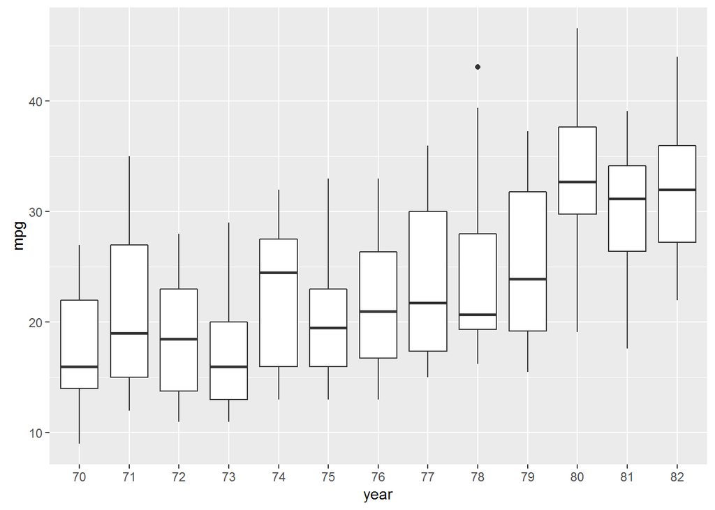

```r
# mpg by year
p4 <- ggplot(mpg, aes(year,mpg))
p4 + geom_boxplot()
```

### Fit Regression Models

In this section we divide randomly divide the data into training and test sets and then fit several regression models to the training data. Holding out some data enables us to assess the performance of these models by seeing how well they predict mpg for the test data. This kind of process is essential if you want to get an idea of how well the model will perform on data that it hasn’t seen before.

The function, index, which is given above randomly splits the mpg data into two subsets: train and test. mpg[ins$train,] means index into the mpg data and return all of the columns of mpg but only the rows to be used for training the model.

We select the model that has the best adjusted R squared value. The first model uses just the numeric data.

```r
ind <- index(mpg)  # Split the mpg data into training and test data.
form.1 <- formula("mpg ~ cyl + disp + hp + weight + accel")
lm.fit.1  <- lm(formula=form.1,data=mpg[ind$train,])   # Build the model
summary(lm.fit.1)
```

```
##
## Call:
## lm(formula = form.1, data = mpg[ind$train, ])
##
## Residuals:
##      Min       1Q   Median       3Q      Max
## -11.1775  -2.6531  -0.3383   2.1213  16.6647
##
## Coefficients:
##               Estimate Std. Error t value Pr(>|t|)
## (Intercept) 45.6903748  3.2039190  14.261  < 2e-16 ***
## cyl         -0.2939068  0.4886196  -0.602   0.5480
## disp        -0.0007986  0.0107036  -0.075   0.9406
## hp          -0.0465635  0.0197161  -2.362   0.0189 *
## weight      -0.0051128  0.0009474  -5.397 1.49e-07 ***
## accel       -0.0388959  0.1514804  -0.257   0.7976
## ---
## Signif. codes:  0 '***' 0.001 '**' 0.01 '*' 0.05 '.' 0.1 ' ' 1
##
## Residual standard error: 4.189 on 268 degrees of freedom
## Multiple R-squared:  0.6986, Adjusted R-squared:  0.693
## F-statistic: 124.2 on 5 and 268 DF,  p-value: < 2.2e-16
```

The second model looks at the effect of year. Note that the - 1 in the formula instructs R to build a model without an intercept term. This is an example of a “fixed effects model”.

```r
form.2 <- formula("mpg ~ cyl + disp + hp + weight + accel + year -1" )
lm.fit.2  <- lm(formula=form.2,data=mpg[ind$train,])   # Build the model
summary(lm.fit.2)
```

```
##
## Call:
## lm(formula = form.2, data = mpg[ind$train, ])
##
## Residuals:
##      Min       1Q   Median       3Q      Max
## -10.6163  -1.8019  -0.1067   1.7977  10.7326
##
## Coefficients:
##          Estimate Std. Error t value Pr(>|t|)
## cyl    -0.0739300  0.3426566  -0.216    0.829
## disp   -0.0020864  0.0075574  -0.276    0.783
## hp     -0.0037610  0.0149929  -0.251    0.802
## weight -0.0057473  0.0007068  -8.131 1.83e-14 ***
## accel   0.0237950  0.1053887   0.226    0.822
## year70 38.5638915  2.4259509  15.896  < 2e-16 ***
## year71 39.3339523  2.2954269  17.136  < 2e-16 ***
## year72 38.0611936  2.4000826  15.858  < 2e-16 ***
## year73 37.6463784  2.3562799  15.977  < 2e-16 ***
## year74 40.3523078  2.3219552  17.379  < 2e-16 ***
## year75 39.2987434  2.2883231  17.174  < 2e-16 ***
## year76 40.2410957  2.3482330  17.137  < 2e-16 ***
## year77 41.2668828  2.3549566  17.523  < 2e-16 ***
## year78 40.8580961  2.3711383  17.231  < 2e-16 ***
## year79 43.4540327  2.3412161  18.560  < 2e-16 ***
## year80 49.9545368  2.3588514  21.177  < 2e-16 ***
## year81 45.8647090  2.2681179  20.221  < 2e-16 ***
## year82 45.5438619  2.2886842  19.900  < 2e-16 ***
## ---
## Signif. codes:  0 '***' 0.001 '**' 0.01 '*' 0.05 '.' 0.1 ' ' 1
##
## Residual standard error: 2.865 on 256 degrees of freedom
## Multiple R-squared:  0.9874, Adjusted R-squared:  0.9865
## F-statistic:  1115 on 18 and 256 DF,  p-value: < 2.2e-16
```

The third model looks at the effect of origin.

```r
form.3 <- formula("mpg ~ cyl + disp + hp + weight + accel + origin -1" )
lm.fit.3  <- lm(formula=form.3,data=mpg[ind$train,])   # Build the model
summary(lm.fit.3)
```

```
##
## Call:
## lm(formula = form.3, data = mpg[ind$train, ])
##
## Residuals:
##     Min      1Q  Median      3Q     Max
## -12.229  -2.857  -0.358   2.116  15.329
##
## Coefficients:
##           Estimate Std. Error t value Pr(>|t|)
## cyl     -0.4413811  0.4847094  -0.911  0.36333
## disp     0.0073816  0.0114530   0.645  0.51980
## hp      -0.0576462  0.0199903  -2.884  0.00425 **
## weight  -0.0047666  0.0009516  -5.009 9.98e-07 ***
## accel   -0.0326393  0.1497241  -0.218  0.82760
## origin1 44.3541671  3.2036497  13.845  < 2e-16 ***
## origin2 45.0719262  3.2078219  14.051  < 2e-16 ***
## origin3 46.7899360  3.1839254  14.696  < 2e-16 ***
## ---
## Signif. codes:  0 '***' 0.001 '**' 0.01 '*' 0.05 '.' 0.1 ' ' 1
##
## Residual standard error: 4.134 on 266 degrees of freedom
## Multiple R-squared:  0.9727, Adjusted R-squared:  0.9719
## F-statistic:  1186 on 8 and 266 DF,  p-value: < 2.2e-16
```

### Model Diagnostics

Model 2 had the best adjusted R squared. In this section we create the standard model diagnostic plots to evaluate how well the model fits the assumptions underlying regressin models. Look here http://www.stat.columbia.edu/~martin/W2024/R7.pdf for some information on interpreting the diagnostic plots. Except for a few outliers flagged by by the plotting software everything looks pretty good.

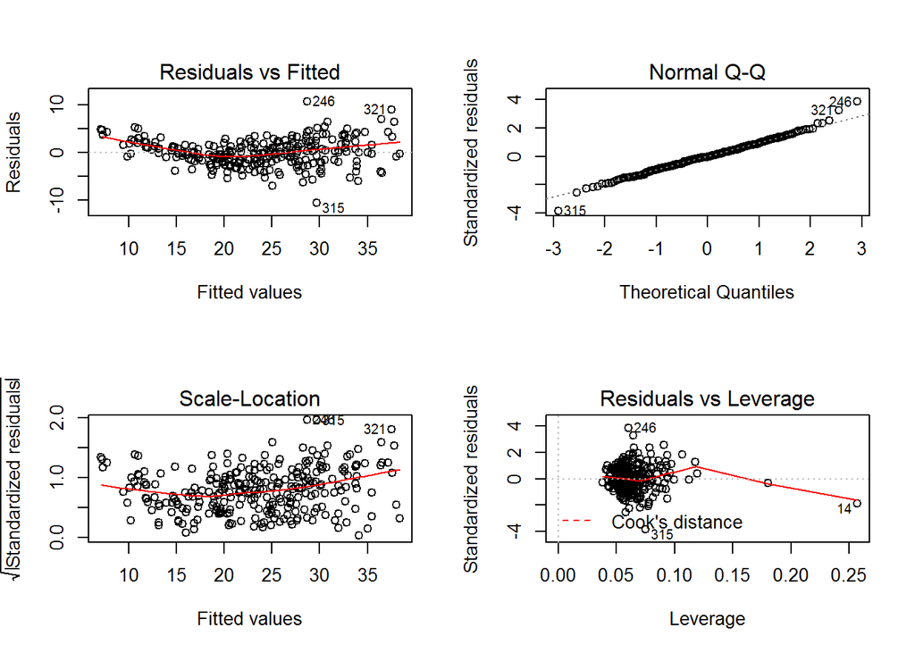

```r
# Plot the regression diagnostics
par(mfrow=c(2,2))
c <- plot(lm.fit.2)
```

```r
par(mfrow=c(1,1))

# Look at the outliers flagged in the diagnostic plots
outliers <- c(14,243,332,389)
mpg[outliers,]
```

```
##      mpg cyl disp  hp weight accel year origin
## 14  14.0   8  455 225   3086  10.0   70      1
## 243 43.1   4   90  48   1985  21.5   78      2
## 332 23.7   3   70 100   2420  12.5   80      3
## 389 44.0   4   97  52   2130  24.6   82      2
##                                name
## 14          buick estate wagon (sw)
## 243 volkswagen rabbit custom diesel
## 332                   mazda rx-7 gs
## 389                       vw pickup
```

### Assess Model Performance

Here we get an idea of how well the model will do on new data by using the predict function to “score” the new data set. We then plot the actual reported values of MPG against the values predicted by the regression with confidence intervals.

```r
predictions <- predict(lm.fit.2,mpg[ind$test,],se.fit=TRUE,interval="prediction")
# Create a data frame to hold the predictions
df <- data.frame(y = mpg[ind$test,]$mpg, predictions)
head(df,2)
```

```
##    y  fit.fit   fit.lwr  fit.upr    se.fit  df residual.scale
## 1 18 16.98991 11.123594 22.85623 0.8167767 256       2.864762
## 7 14 11.38811  5.497111 17.27911 0.8613697 256       2.864762
```

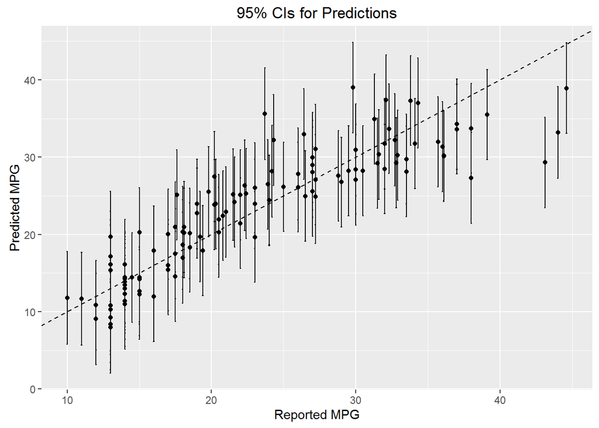

```r
#Plot predictions vs actuals
# error bars = 1 standard deviation
p5 <- ggplot(df, aes(x = y, y = fit.fit))
p5 + geom_errorbar(aes(ymin = fit.lwr, ymax = fit.upr), width = .1) +
  geom_point() +
  geom_abline(intercept = 0, slope = 1, linetype=2) +
  xlab("Reported MPG") +
  ylab("Predicted MPG") +
  ggtitle("95% CIs for Predictions")
```

This model looks pretty good! The 45 degree line, which indicates a perfect predictions, is mostly covered bu the confidence intervals. For homework, try creating some more exploratory plots and building additional regression models. What happens when you include both year and origin in a model?